# BMI: Body Mass Index

# 1 Description of DataSchema variable

The description of harmonised variable is the following:

- Short name: `bmi`
- Variable label: `Body Mass Index calculated as weight (kg)/height(m)^2`
- Variable description: `the BMI variable should be created by dividing weight and heigh variables with the following equation= weight (kg)/height(m)^2`
- Domain: `Physical measures`
- Value type: `Continuous`
- Category missings:

| **Code** | **Category Label** |
| --- | --- |
| 991 | CAPI/interviewer error |
| 992 | Impute |
| 993 | Disable to measure |
| 994 | Not attempt/not done |
| 995 | Does not answer |
| 996 | Not applicable |
| 997 | Refuse |
| 998 | Do not know |
| 999 | Missing |

# 2 Data process

## 2.1 England

### 2.1.1 Wave 1

There is no variable.

### 2.1.2 Wave 2

#### 2.1.2.1 Study-specific variable description

The study-specific variable elected to be harmonised is:

- Name: `bmival`
- Label: `(D) Valid BMI - inc estimated>130kg`
- Type of variable: `countinous`
- Missings
  - `-1 = Not Applicable`

```
## $summary
##    Min. 1st Qu.  Median    Mean 3rd Qu.    Max.
##   14.87   24.67   27.28   27.93   30.56   56.15
##
## $values_table
##            No-missings     -1 NA
## Frequency      7225.00 441.00  0
## Percentage       94.25   5.75  0
##
## $n_table
##      Sample size Missing values
## [1,]        7666            441
```

[figure not shown]

#### 2.1.2.2 Harmonisation algorithm

The harmonized variable is the same than the study-specific variable, but the missing values have to be recoded as follows:

- `recode -1 "Not Applicable" into 996`
- `NA into 999`

**R script:**

```r
ELSA_ds_w2 <- tibble(id = ELSA_w2_bmi$id)
ELSA_ds_w2$bmi <- car::recode(ELSA_w2_bmi$bmival, "NA=999; -1=996")
ELSA_ds_w2$bmi <- labelled(ELSA_ds_w2$bmi, labels = c(Missing = 999, `Do not know` = 998,
    Refuse = 997, `Not applicable` = 996, `Does not answer` = 995, `Not attempt not done` = 994,
    `Disable to measure` = 993, Impute = 992, `CAPI interviewer error` = 991))
```

#### 2.1.2.3 Statistics of the new harmonised variable

```
## $summary
##    Min. 1st Qu.  Median    Mean 3rd Qu.    Max.
##   14.87   24.67   27.28   27.93   30.56   56.15
##
## $values_table
##            No-missings 991 992 993 994 995    996 997 998 999 NA
## Frequency      7225.00   0   0   0   0   0 441.00   0   0   0  0
## Percentage       94.25   0   0   0   0   0   5.75   0   0   0  0
##
## $n_table
##      Sample size Missing values
## [1,]        7666            441
```

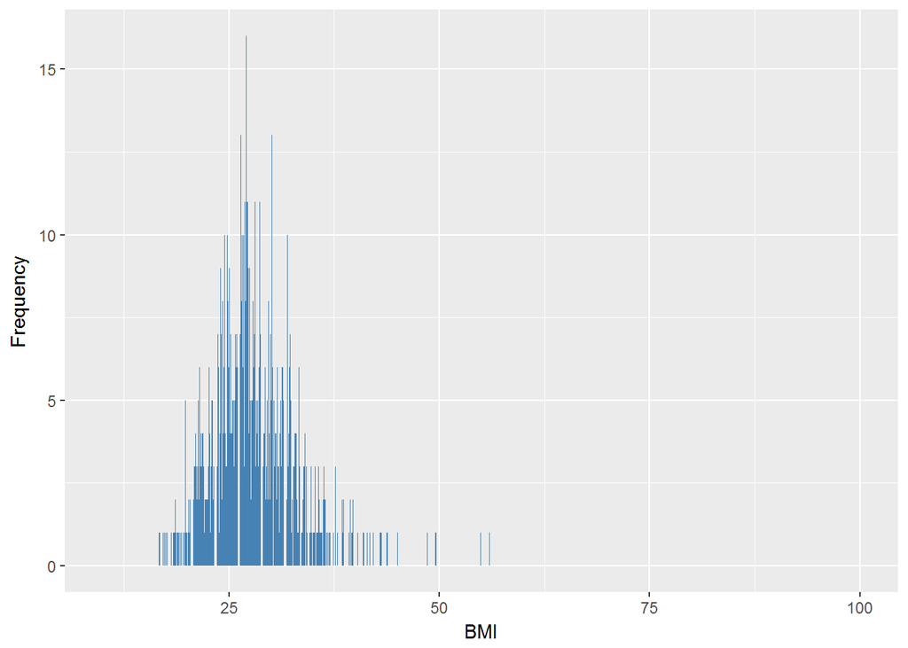

#### 2.1.2.4 Validation

It is going to check if weight and heigth values are correct by computing BMI with the formula: weight/height^2.

```
## # A tibble: 6 x 6
##   id         htval    weight bmival     bmi_c     proff
##   <chr>  <dbl+lbl> <dbl+lbl>  <dbl> <dbl+lbl> <dbl+lbl>
## 1 104025       168    - 1.00  49.0     - 1.00      50.0
## 2 104096       154     60.5  - 1.00     25.5      -26.5
## 3 104383       168    - 1.00  47.9     - 1.00      48.9
## 4 104604       188    - 1.00  37.9     - 1.00      38.9
## 5 105283       145     69.9  - 1.00     33.3      -34.3
## 6 105305       162     77.5  - 1.00     29.7      -30.7
```

There are 32 individuals that the bmi value is different than the computed by the formula. Those discrepancies are because either bmi is missing (-1) or weight or height is missing (-1). Therefore, it is going to be used this values to complet the variables bmi, weight and height.

### 2.1.3 Wave 3

There is no variable.

### 2.1.4 Wave 4

#### 2.1.4.1 Study-specific variable description

The study-specific variable elected to be harmonised is:

- Name: `bmival`
- Label: `(D) Valid BMI - inc estimated>130kg`
- Type of variable: `countinous`
- Missings
  - `-1 = Not Applicable`

```
## $summary
##    Min. 1st Qu.  Median    Mean 3rd Qu.    Max.
##   14.70   24.70   27.50   28.27   31.00   71.10
##
## $values_table
##            No-missings     -1 NA
## Frequency      8262.00 381.00  0
## Percentage       95.59   4.41  0
##
## $n_table
##      Sample size Missing values
## [1,]        8643            381
```

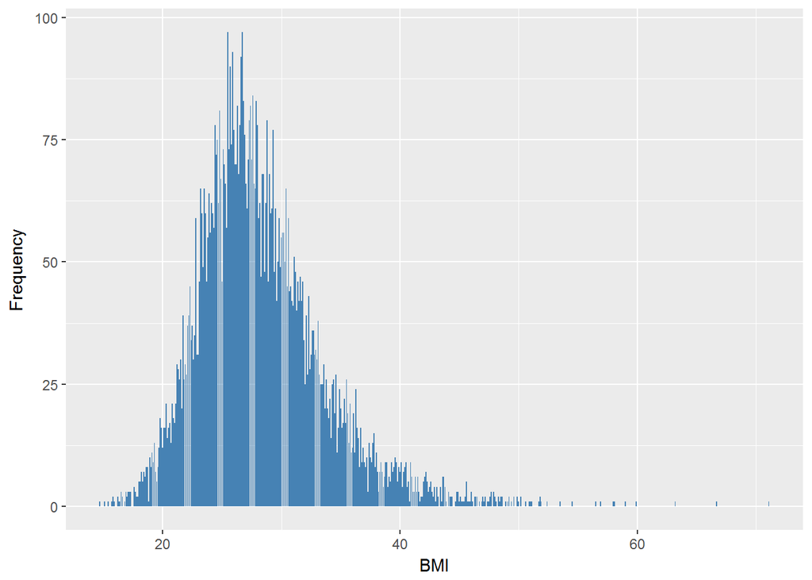

#### 2.1.4.2 Harmonisation algorithm

The harmonized variable is the same than the study-specific variable, but the missing values have to be recoded as follows:

- `recode -1 "Not Applicable" into 996`
- `NA into 999`

**R script:**

```r
ELSA_ds_w4 <- tibble(id = ELSA_w4_bmi$id)
ELSA_ds_w4$bmi <- car::recode(ELSA_w4_bmi$bmival, "NA=999; -1=996")
ELSA_ds_w4$bmi <- labelled(ELSA_ds_w4$bmi, labels = c(Missing = 999, `Do not know` = 998,
    Refuse = 997, `Not applicable` = 996, `Does not answer` = 995, `Not attempt not done` = 994,
    `Disable to measure` = 993, Impute = 992, `CAPI interviewer error` = 991))
```

#### 2.1.4.3 Statistics of the new harmonised variable

```
## $summary
##    Min. 1st Qu.  Median    Mean 3rd Qu.    Max.
##   14.70   24.70   27.50   28.27   31.00   71.10
##
## $values_table
##            No-missings 991 992 993 994 995    996 997 998 999 NA
## Frequency      8262.00   0   0   0   0   0 381.00   0   0   0  0
## Percentage       95.59   0   0   0   0   0   4.41   0   0   0  0
##
## $n_table
##      Sample size Missing values
## [1,]        8643            381
```

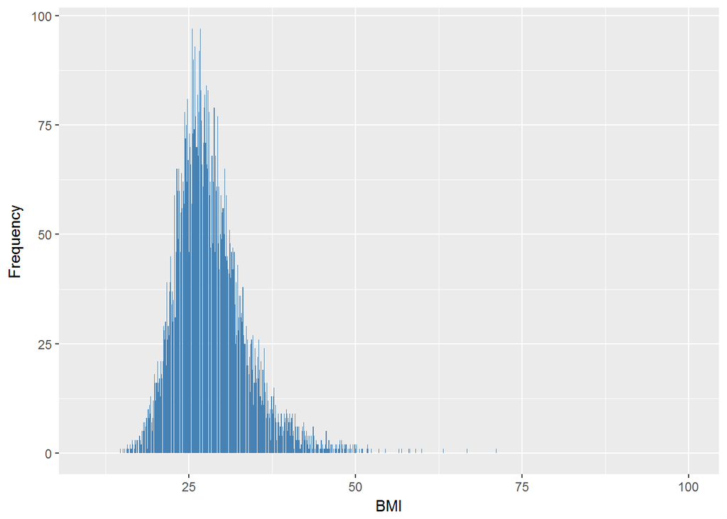

#### 2.1.4.4 Validation

It is going to check if weight and heigth values are correct by computing BMI with the formula: weight/height^2.

```
## # A tibble: 6 x 6
##   id         htval    weight    bmival     bmi_c     proff
##   <chr>  <dbl+lbl> <dbl+lbl> <dbl+lbl> <dbl+lbl> <dbl+lbl>
## 1 103737       168     60.1     - 1.00     21.3      -22.3
## 2 103780       175    - 1.00     46.9     - 1.00      47.9
## 3 104439       152     64.0     - 1.00     27.7      -28.7
## 4 104784       170    - 1.00     45.6     - 1.00      46.6
## 5 104874       167    - 1.00     48.6     - 1.00      49.6
## 6 106528       171    - 1.00     56.5     - 1.00      57.5
```

There are 49 individuals that the bmi value is different than the computed by the formula. Those discrepancies are because either bmi is missing (-1) or weight or height is missing (-1). Therefore, it is going to be used this values to complet the variables bmi, weight and height.

### 2.1.5 Wave 5

There is no variable.

### 2.1.6 Wave 6

#### 2.1.6.1 Study-specific variable description

The study-specific variable elected to be harmonised is:

- Name: `BMIVAL`
- Label: `(D) Valid BMI - inc estimated>130kg`
- Type of variable: `countinous`
- Missings
  - `-1 = Not Applicable`

```
## $summary
##    Min. 1st Qu.  Median    Mean 3rd Qu.    Max.
##   15.10   24.70   27.50   28.29   31.00   59.40
##
## $values_table
##            No-missings     -1 NA
## Frequency      7693.00 361.00  0
## Percentage       95.52   4.48  0
##
## $n_table
##      Sample size Missing values
## [1,]        8054            361
```

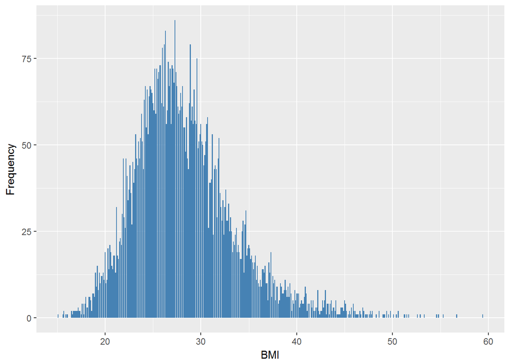

#### 2.1.6.2 Harmonisation algorithm

The harmonized variable is the same than the study-specific variable, but the missing values have to be recoded as follows:

- `recode -1 "Not Applicable" into 996`
- `NA into 999`

**R script:**

```r
ELSA_ds_w6 <- tibble(id = ELSA_w6_bmi$id)
ELSA_ds_w6$bmi <- car::recode(ELSA_w6_bmi$BMIVAL, "NA=999; -1=996")
ELSA_ds_w6$bmi <- labelled(ELSA_ds_w6$bmi, labels = c(Missing = 999, `Do not know` = 998,
    Refuse = 997, `Not applicable` = 996, `Does not answer` = 995, `Not attempt not done` = 994,
    `Disable to measure` = 993, Impute = 992, `CAPI interviewer error` = 991))
```

#### 2.1.6.3 Statistics of the new harmonised variable

```
## $summary
##    Min. 1st Qu.  Median    Mean 3rd Qu.    Max.
##   15.10   24.70   27.50   28.29   31.00   59.40
##
## $values_table
##            No-missings 991 992 993 994 995    996 997 998 999 NA
## Frequency      7693.00   0   0   0   0   0 361.00   0   0   0  0
## Percentage       95.52   0   0   0   0   0   4.48   0   0   0  0
##
## $n_table
##      Sample size Missing values
## [1,]        8054            361
```

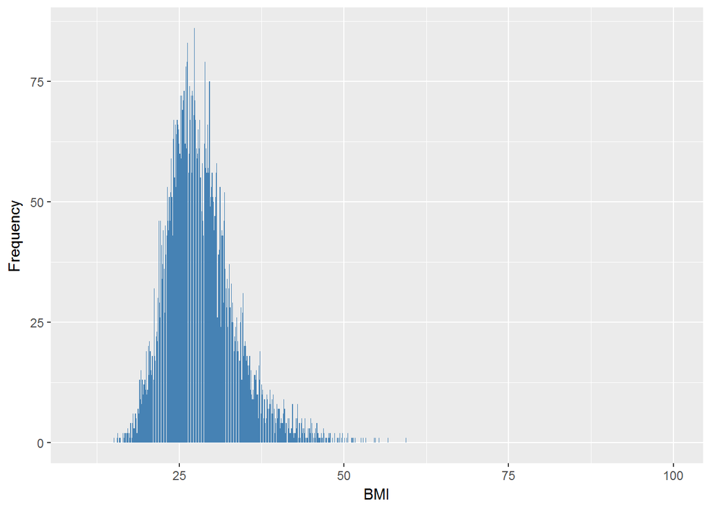

#### 2.1.6.4 Validation

It is going to check if weight and heigth values are correct by computing BMI with the formula: weight/height^2.

```
## # A tibble: 6 x 6
##   id      weight HTVAL BMIVAL  bmi_c proff
##   <chr>    <dbl> <dbl>  <dbl>  <dbl> <dbl>
## 1 104395 -  1.00   174  44.0  - 1.00  45.0
## 2 104784 -  1.00   166  51.2  - 1.00  52.2
## 3 104792   60.8    170 - 1.00  21.1  -22.1
## 4 104874 -  1.00   168  50.6  - 1.00  51.6
## 5 105877   67.9    143 - 1.00  33.4  -34.4
## 6 106038  130      180 - 1.00  40.1  -41.1
```

There are 66 individuals that the bmi value is different than the computed by the formula. Those discrepancies are because either bmi is missing (-1) or weight or height is missing (-1). Therefore, it is going to be used this values to complet the variables bmi, weight and height.

### 2.1.7 Wave 7

Not found.

# 3 Quality estimation